# OZNAL projekt 2

Peter Slovák, Pavol Hradský

2024-04-13

# Regresia bola odstránená z dôvodu prehľadnosti, EDA bola ponechaná a rozšírená.

## Bc. Peter Slovák, Bc. Pavol Hradský

# Načítanie dát, pred úpravou

```r
data <- read_csv("Life Expectancy Data.csv", col_names = TRUE)
data
```

```
## # A tibble: 2,938 × 22
##    Country      Year Status  `Life expectancy` `Adult Mortality` `infant deaths`
##    <chr>       <dbl> <chr>               <dbl>             <dbl>           <dbl>
##  1 Afghanistan  2015 Develo…              65                 263              62
##  2 Afghanistan  2014 Develo…              59.9               271              64
##  3 Afghanistan  2013 Develo…              59.9               268              66
##  4 Afghanistan  2012 Develo…              59.5               272              69
##  5 Afghanistan  2011 Develo…              59.2               275              71
##  6 Afghanistan  2010 Develo…              58.8               279              74
##  7 Afghanistan  2009 Develo…              58.6               281              77
##  8 Afghanistan  2008 Develo…              58.1               287              80
##  9 Afghanistan  2007 Develo…              57.5               295              82
## 10 Afghanistan  2006 Develo…              57.3               295              84
## # ℹ 2,928 more rows
## # ℹ 16 more variables: Alcohol <dbl>, `percentage expenditure` <dbl>,
## #   `Hepatitis B` <dbl>, Measles <dbl>, BMI <dbl>, `under-five deaths` <dbl>,
## #   Polio <dbl>, `Total expenditure` <dbl>, Diphtheria <dbl>, `HIV/AIDS` <dbl>,
## #   GDP <dbl>, Population <dbl>, `thinness  1-19 years` <dbl>,
## #   `thinness 5-9 years` <dbl>, `Income composition of resources` <dbl>,
## #   Schooling <dbl>
```

# Čo je v našich dátach?

```r
str(data) # struktura dát
```

```
## spc_tbl_ [2,938 × 22] (S3: spec_tbl_df/tbl_df/tbl/data.frame)
##  $ Country                        : chr [1:2938] "Afghanistan" "Afghanistan" "Afghanistan" "Afghanistan" ...
##  $ Year                           : num [1:2938] 2015 2014 2013 2012 2011 ...
##  $ Status                         : chr [1:2938] "Developing" "Developing" "Developing" "Developing" ...
##  $ Life expectancy                : num [1:2938] 65 59.9 59.9 59.5 59.2 58.8 58.6 58.1 57.5 57.3 ...
##  $ Adult Mortality                : num [1:2938] 263 271 268 272 275 279 281 287 295 295 ...
##  $ infant deaths                  : num [1:2938] 62 64 66 69 71 74 77 80 82 84 ...
##  $ Alcohol                        : num [1:2938] 0.01 0.01 0.01 0.01 0.01 0.01 0.01 0.03 0.02 0.03 ...
##  $ percentage expenditure         : num [1:2938] 71.3 73.5 73.2 78.2 7.1 ...
##  $ Hepatitis B                    : num [1:2938] 65 62 64 67 68 66 63 64 63 64 ...
##  $ Measles                        : num [1:2938] 1154 492 430 2787 3013 ...
##  $ BMI                            : num [1:2938] 19.1 18.6 18.1 17.6 17.2 16.7 16.2 15.7 15.2 14.7 ...
##  $ under-five deaths              : num [1:2938] 83 86 89 93 97 102 106 110 113 116 ...
##  $ Polio                          : num [1:2938] 6 58 62 67 68 66 63 64 63 58 ...
##  $ Total expenditure              : num [1:2938] 8.16 8.18 8.13 8.52 7.87 9.2 9.42 8.33 6.73 7.43 ...
##  $ Diphtheria                     : num [1:2938] 65 62 64 67 68 66 63 64 63 58 ...
##  $ HIV/AIDS                       : num [1:2938] 0.1 0.1 0.1 0.1 0.1 0.1 0.1 0.1 0.1 0.1 ...
##  $ GDP                            : num [1:2938] 584.3 612.7 631.7 670 63.5 ...
##  $ Population                     : num [1:2938] 33736494 327582 31731688 3696958 2978599 ...
##  $ thinness  1-19 years           : num [1:2938] 17.2 17.5 17.7 17.9 18.2 18.4 18.6 18.8 19 19.2 ...
##  $ thinness 5-9 years             : num [1:2938] 17.3 17.5 17.7 18 18.2 18.4 18.7 18.9 19.1 19.3 ...
##  $ Income composition of resources: num [1:2938] 0.479 0.476 0.47 0.463 0.454 0.448 0.434 0.433 0.415 0.405 ...
##  $ Schooling                      : num [1:2938] 10.1 10 9.9 9.8 9.5 9.2 8.9 8.7 8.4 8.1 ...
##  - attr(*, "spec")=
##   .. cols(
##   ..   Country = col_character(),
##   ..   Year = col_double(),
##   ..   Status = col_character(),
##   ..   `Life expectancy` = col_double(),
##   ..   `Adult Mortality` = col_double(),
##   ..   `infant deaths` = col_double(),
##   ..   Alcohol = col_double(),
##   ..   `percentage expenditure` = col_double(),
##   ..   `Hepatitis B` = col_double(),
##   ..   Measles = col_double(),
##   ..   BMI = col_double(),
##   ..   `under-five deaths` = col_double(),
##   ..   Polio = col_double(),
##   ..   `Total expenditure` = col_double(),
##   ..   Diphtheria = col_double(),
##   ..   `HIV/AIDS` = col_double(),
##   ..   GDP = col_double(),
##   ..   Population = col_double(),
##   ..   `thinness  1-19 years` = col_double(),
##   ..   `thinness 5-9 years` = col_double(),
##   ..   `Income composition of resources` = col_double(),
##   ..   Schooling = col_double()
##   .. )
##  - attr(*, "problems")=<externalptr>
```

```r
head(data)
```

```
## # A tibble: 6 × 22
##   Country      Year Status   `Life expectancy` `Adult Mortality` `infant deaths`
##   <chr>       <dbl> <chr>                <dbl>             <dbl>           <dbl>
## 1 Afghanistan  2015 Develop…              65                 263              62
## 2 Afghanistan  2014 Develop…              59.9               271              64
## 3 Afghanistan  2013 Develop…              59.9               268              66
## 4 Afghanistan  2012 Develop…              59.5               272              69
## 5 Afghanistan  2011 Develop…              59.2               275              71
## 6 Afghanistan  2010 Develop…              58.8               279              74
## # ℹ 16 more variables: Alcohol <dbl>, `percentage expenditure` <dbl>,
## #   `Hepatitis B` <dbl>, Measles <dbl>, BMI <dbl>, `under-five deaths` <dbl>,
## #   Polio <dbl>, `Total expenditure` <dbl>, Diphtheria <dbl>, `HIV/AIDS` <dbl>,
## #   GDP <dbl>, Population <dbl>, `thinness  1-19 years` <dbl>,
## #   `thinness 5-9 years` <dbl>, `Income composition of resources` <dbl>,
## #   Schooling <dbl>
```

```r
dim(data) # rozmery dát
```

```
## [1] 2938   22
```

```r
sapply(data, class) # vela numerickych dat, vypisane podrobne
```

```
##                         Country                            Year
##                     "character"                       "numeric"
##                          Status                 Life expectancy
##                     "character"                       "numeric"
##                 Adult Mortality                   infant deaths
##                       "numeric"                       "numeric"
##                         Alcohol          percentage expenditure
##                       "numeric"                       "numeric"
##                     Hepatitis B                         Measles
##                       "numeric"                       "numeric"
##                             BMI               under-five deaths
##                       "numeric"                       "numeric"
##                           Polio               Total expenditure
##                       "numeric"                       "numeric"
##                      Diphtheria                        HIV/AIDS
##                       "numeric"                       "numeric"
##                             GDP                      Population
##                       "numeric"                       "numeric"
##            thinness  1-19 years              thinness 5-9 years
##                       "numeric"                       "numeric"
## Income composition of resources                       Schooling
##                       "numeric"                       "numeric"
```

Dáta obsahujú **22 stĺpcov** a **2938 záznamov** o kvalite a dĺžke života v **193 krajinách** naprieč rokmi **2000-2015**.

```r
table(sapply(data, class))
```

```
##
## character   numeric
##         2        20
```

**20 stĺpcov** je **numerických** a **2 kategorické**. Niektoré stĺpce obsahujú aj **NA** hodnoty.

**Kategorické stĺpce:** Country, Status.

**Numerické stĺpce:** Year, Life expectancy, Adult Mortality, infant deaths, Alcohol, percentage expenditure, Hepatitis B, Measles, BMI, under-five deaths, Polio, Total expenditure, Diphtheria, HIV/AIDS, GDP, Population, thinness 1-19 years, thinness 5-9 years, Income composition of resources, Schooling.

```r
# Ideme zistit, ci sa v stlpci Life expectancy nachadzaju nejake chybajuce hodnoty, alebo prazdne hodnoty pretoze to je stlpec, ktory budeme predikovat a je pre nas dolezity

# kontrola pre chybajuce hodnoty v stlpci Life expectancy. Zistili sme, ze v stlpci Life expectancy sa nachadza 10 chybajucich hodnot - NA
sum(is.na(data$`Life expectancy`))
```

```
## [1] 10
```

```r
# kontrola pre prazdne hodnoty
sum(str_detect(data$`Life expectancy`, "^\\s*$"))
```

```
## [1] NA
```

# Čistenie datasetu

- odstránenie riadkov s chýbajúcimi hodnotami v stĺpci Life expectancy

```r
data <- data %>% drop_na(`Life expectancy`)
missing_values_life_axpextancy <- sum(is.na(data$`Life expectancy`))
missing_values_life_axpextancy
```

```
## [1] 0
```

```r
dim(data)
```

```
## [1] 2928   22
```

# Histogramy

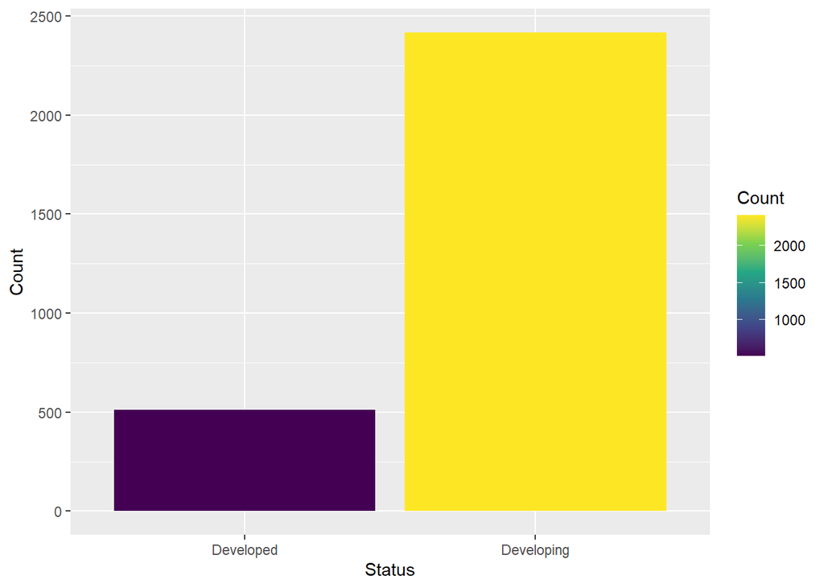

```r
# Histogram rozvojových a rozvinutých krajín
data %>%
  count(Status) %>%
  rename(Count = n) %>%
  ggplot(aes(x=Status, y=Count)) +
  geom_histogram(stat="identity", aes(fill=Count)) +
  scale_fill_viridis_c()
```

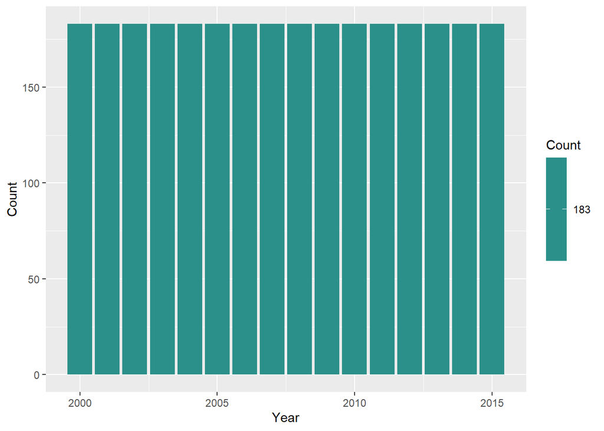

```r
# Histogram rokov, kedy boli robené merania
data %>%
  count(Year) %>%
  rename(Count = n) %>%
  ggplot(aes(x=Year, y=Count)) +
  geom_histogram(stat="identity", aes(fill=Count)) +
  scale_fill_viridis_c()
```

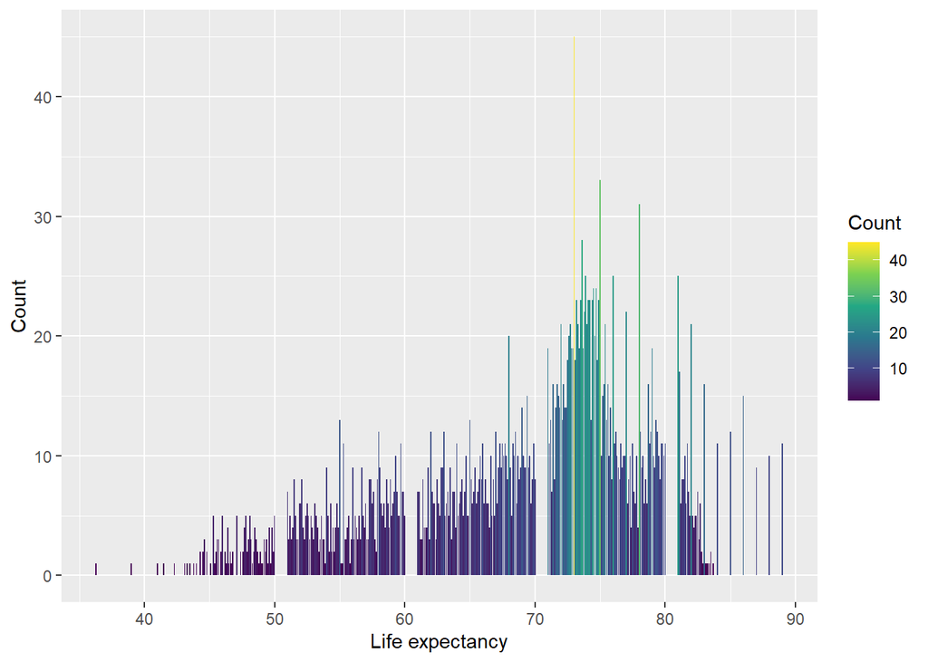

```r
# Histogram dĺžky života
data %>%
  count(`Life expectancy`) %>%
  rename(Count = n) %>%
  ggplot(aes(x=`Life expectancy`, y=Count)) +
  geom_histogram(stat="identity", aes(fill=Count)) +
  scale_fill_viridis_c()
```

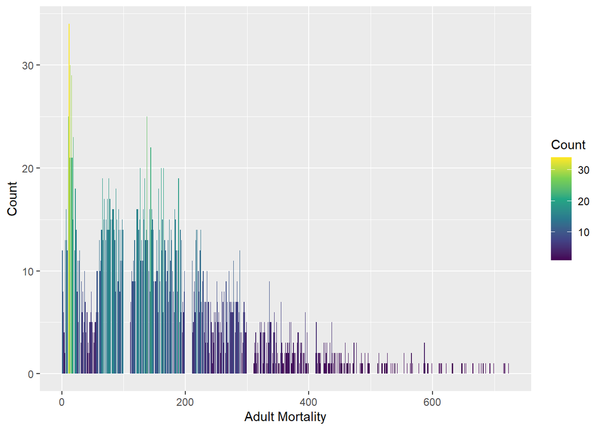

```r
# Histogram adult mortality
data %>%
  count(`Adult Mortality`) %>%
  rename(Count = n) %>%
  ggplot(aes(x=`Adult Mortality`, y=Count)) +
  geom_histogram(stat="identity", aes(fill=Count)) +
  scale_fill_viridis_c()
```

Pri zobrazení histogramov vidíme, že v datasete je **omnoho viac záznamov s rozvojových krajín ako z rozvinutých**. **Roky**, v ktorých boli robené merania, sú zastúpené **rovnomerne**. Pred odstránením predchádzajúcich 10 riadkov pre chýbajúce záznamy v Life expectancy sme mali v jeden rok viac záznamov. Ďalej vidíme rozdelenie dĺžky života a adult mortality.

# Zvyšné chýbajúce hodnoty

```
##                         Country                            Year
##                               0                               0
##                          Status                 Life expectancy
##                               0                               0
##                 Adult Mortality                   infant deaths
##                               0                               0
##                         Alcohol          percentage expenditure
##                             193                               0
##                     Hepatitis B                         Measles
##                             553                               0
##                             BMI               under-five deaths
##                              32                               0
##                           Polio               Total expenditure
##                              19                             226
##                      Diphtheria                        HIV/AIDS
##                              19                               0
##                             GDP                      Population
##                             443                             644
##            thinness  1-19 years              thinness 5-9 years
##                              32                              32
## Income composition of resources                       Schooling
##                             160                             160
```

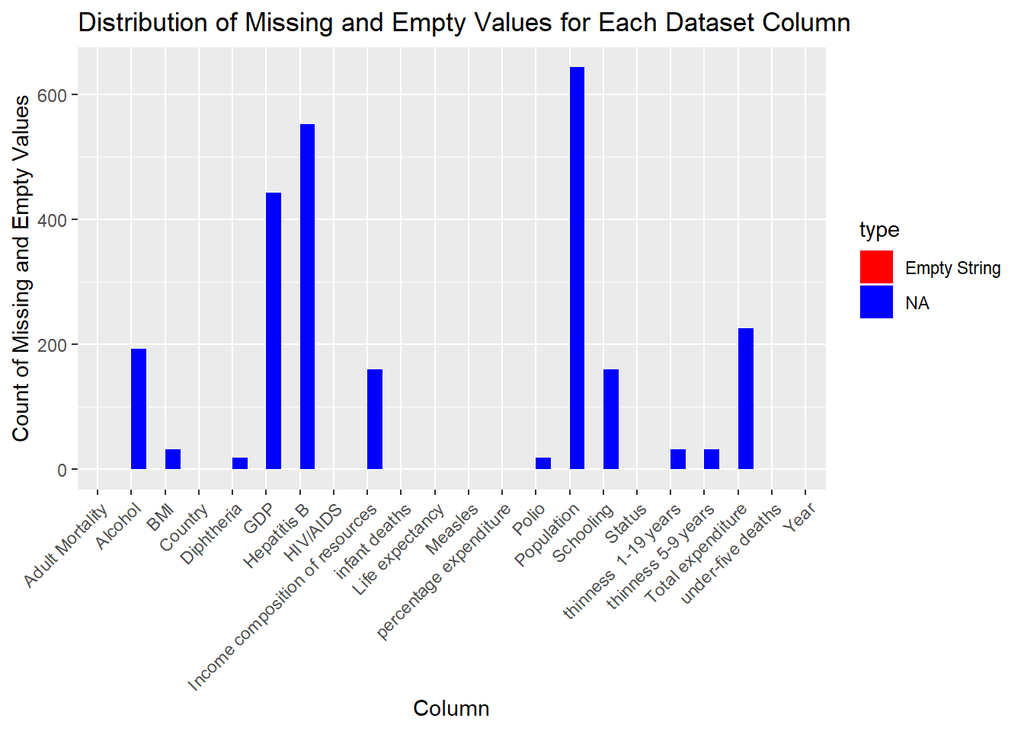

Kontrolovali sme aj ostatné chýbajúce hodnoty. Vidíme, že pomerne dosť sa ich nachádza aj v stĺpcoch **Population** a **hepatits B** alebo **GDB**. V ostaných je len menej, alebo žiadne.

Drop NA rows pre použité stĺpce v modeli, kvôli prevencii proti odstráneniu počas predikcii:

```r
library(conflicted)
data %<>%
  dplyr::select(Status, `Life expectancy`, `Adult Mortality`, Alcohol,
         `percentage expenditure`, BMI, `Total expenditure`,
         Diphtheria, `HIV/AIDS`, GDP, `Income composition of resources`,
         Schooling) %>%
  drop_na()
```

## Pairplot

- identifikácia vzťahov a vzorov medzi premennými

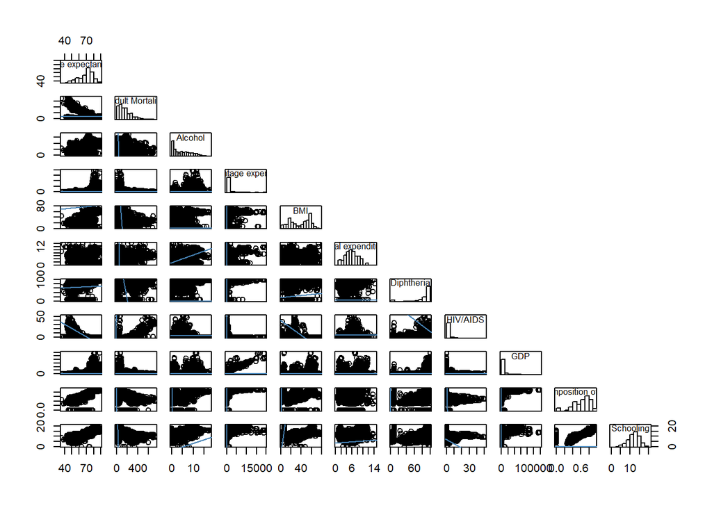

```r
#-----Helper functions----- z cvika, labov prebrate
panel.cor <- function(x,y, digits=2, prefix="", cex.cor){
  usr <- par("usr")
  on.exit(par(usr))
  par(usr = c(0,1,0,1))
  r <- abs(cor(x,y,use="complete.obs"))
  txt <- format(c(r,0.123456789), digits = digits)[1]
  txt <- paste0(prefix, txt,sep="")
  if(missing(cex.cor)) cex.cor <- 0.8/strwidth(txt)
  text(0.5, 0.5, txt, cex = cex.cor * (1 + r) / 2)
}

panel.hist <- function(x, ...){
  usr <- par("usr")
  on.exit(par(usr))
  par(usr = c(usr[1:2],0,1.5))
  h <- hist(x, plot = FALSE)
  breaks <- h$breaks
  nB <- length(breaks)
  y <- h$counts
  y <- y/max(y)
  rect(breaks[-nB], 0, breaks[-1], y, col="white",...)
}

panel.lm <- function(x, y, col = par("col"), bg = NA, pch = par("pch"),
                     cex = 1, col.smooth = "blue", ...) {
  points(x, y, pch = pch, col = col, bg = bg, cex = cex)
  abline(stats::lm(x ~ y), col = "steelblue", ...)
}
pairs(~ `Life expectancy` + `Adult Mortality` + Alcohol  +
        `percentage expenditure` + BMI +
        `Total expenditure` + Diphtheria + `HIV/AIDS` + GDP +
        `Income composition of resources` +
        Schooling,
      data = data,
      upper.panel= NULL,
      diag.panel = panel.hist,
      lower.panel = panel.lm)
```

## Korelačná tabuľka

```r
#options(repos = c(CRAN = "https://cran.rstudio.com")) # uncomment if you don't have the package installed
#install.packages("corrplot") # uncomment if you don't have the package installed
library(corrplot)
# plot with removed na values

cor(data %>% select(`Life expectancy`, `Adult Mortality`, Alcohol,
                    `percentage expenditure`, BMI, `Total expenditure`,
                    Diphtheria, `HIV/AIDS`, GDP, `Income composition of resources`,
                    Schooling), method = "pearson", use = "pairwise.complete.obs") # deals with na values
```

```
##                                 Life expectancy Adult Mortality     Alcohol
## Life expectancy                       1.0000000     -0.68225124  0.38489525
## Adult Mortality                      -0.6822512      1.00000000 -0.17484853
## Alcohol                               0.3848953     -0.17484853  1.00000000
## percentage expenditure                0.4265797     -0.26093992  0.37901202
## BMI                                   0.5802377     -0.38427606  0.34654961
## Total expenditure                     0.1795581     -0.07571995  0.30396046
## Diphtheria                            0.4658321     -0.24653619  0.21433064
## HIV/AIDS                             -0.5766728      0.54350564 -0.04436029
## GDP                                   0.4619693     -0.29246038  0.35408276
## Income composition of resources       0.7324831     -0.45351711  0.45586036
## Schooling                             0.7622228     -0.44583928  0.55667350
##                                 percentage expenditure        BMI
## Life expectancy                              0.4265797  0.5802377
## Adult Mortality                             -0.2609399 -0.3842761
## Alcohol                                      0.3790120  0.3465496
## percentage expenditure                       1.0000000  0.2692574
## BMI                                          0.2692574  1.0000000
## Total expenditure                            0.2109996  0.1918287
## Diphtheria                                   0.1628856  0.2901654
## HIV/AIDS                                    -0.1193884 -0.2469275
## GDP                                          0.9229286  0.3040265
## Income composition of resources              0.4158105  0.5309640
## Schooling                                    0.4272987  0.5811730
##                                 Total expenditure Diphtheria    HIV/AIDS
## Life expectancy                        0.17955813  0.4658321 -0.57667281
## Adult Mortality                       -0.07571995 -0.2465362  0.54350564
## Alcohol                                0.30396046  0.2143306 -0.04436029
## percentage expenditure                 0.21099962  0.1628856 -0.11938842
## BMI                                    0.19182868  0.2901654 -0.24692753
## Total expenditure                      1.00000000  0.1290891  0.02675503
## Diphtheria                             0.12908909  1.0000000 -0.16741776
## HIV/AIDS                               0.02675503 -0.1674178  1.00000000
## GDP                                    0.14137737  0.1983948 -0.13905380
## Income composition of resources        0.17199633  0.4149200 -0.25841709
## Schooling                              0.26989840  0.4327894 -0.23641440
##                                        GDP Income composition of resources
## Life expectancy                  0.4619693                       0.7324831
## Adult Mortality                 -0.2924604                      -0.4535171
## Alcohol                          0.3540828                       0.4558604
## percentage expenditure           0.9229286                       0.4158105
## BMI                              0.3040265                       0.5309640
## Total expenditure                0.1413774                       0.1719963
## Diphtheria                       0.1983948                       0.4149200
## HIV/AIDS                        -0.1390538                      -0.2584171
## GDP                              1.0000000                       0.4615884
## Income composition of resources  0.4615884                       1.0000000
## Schooling                        0.4564390                       0.7924189
##                                  Schooling
## Life expectancy                  0.7622228
## Adult Mortality                 -0.4458393
## Alcohol                          0.5566735
## percentage expenditure           0.4272987
## BMI                              0.5811730
## Total expenditure                0.2698984
## Diphtheria                       0.4327894
## HIV/AIDS                        -0.2364144
## GDP                              0.4564390
## Income composition of resources  0.7924189
## Schooling                        1.0000000
```

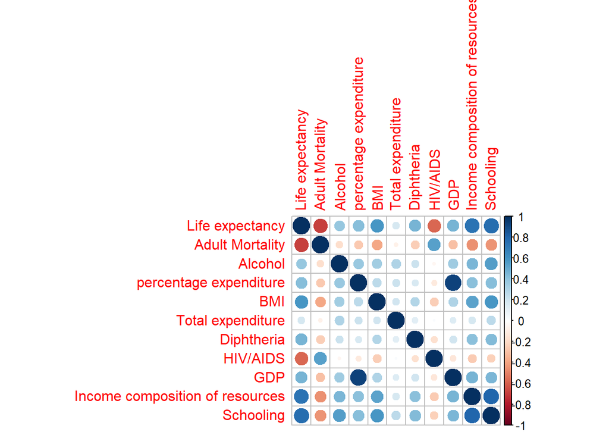

```r
corrplot(cor(data %>% select(`Life expectancy`, `Adult Mortality`, Alcohol,
                    `percentage expenditure`, BMI, `Total expenditure`,
                    Diphtheria, `HIV/AIDS`, GDP, `Income composition of resources`,
                    Schooling), method = "pearson", use = "pairwise.complete.obs")) # deals with na values
```

Pre 1 z experimentov sme vybrali len tie stĺpce, ktoré najviac korelujú a to **GDP** a **percentage expenditure**, ktoré sa budeme snažiť **predikovať** vzhľadom na status rozvinutosti krajiny.

# One hot encode status rozvinutosti krajiny pre klasifikáciu

```r
data %<>%
  mutate(status_oh = if_else(Status=='Developed', 1, 0)) %>%
  relocate(status_oh)
```

# Rozdelenie dát na trénovacie a testovacie

```r
# train test split
set.seed(123)
train_index <- sample(1:nrow(data), 0.8*nrow(data)) # 80% train, 20% test
train_data <- data[train_index,]
test_data <- data[-train_index,]
train_data
```

```
## # A tibble: 1,840 × 13
##    status_oh Status     `Life expectancy` `Adult Mortality` Alcohol
##        <dbl> <chr>                  <dbl>             <dbl>   <dbl>
##  1         0 Developing              76.8               117    6.03
##  2         0 Developing              59.5               272    0.08
##  3         0 Developing              73.5               123    7.59
##  4         0 Developing              59                 251    0.33
##  5         0 Developing              65.1                21    0.46
##  6         1 Developed               81.7                65   11.1
##  7         0 Developing              65.1               225    0.01
##  8         0 Developing              84                  68    2.33
##  9         0 Developing              56.7               337   11.9
## 10         0 Developing              76.8               127    6.87
## # ℹ 1,830 more rows
## # ℹ 8 more variables: `percentage expenditure` <dbl>, BMI <dbl>,
## #   `Total expenditure` <dbl>, Diphtheria <dbl>, `HIV/AIDS` <dbl>, GDP <dbl>,
## #   `Income composition of resources` <dbl>, Schooling <dbl>
```

```r
test_data
```

```
## # A tibble: 461 × 13
##    status_oh Status     `Life expectancy` `Adult Mortality` Alcohol
##        <dbl> <chr>                  <dbl>             <dbl>   <dbl>
##  1         0 Developing              59.9               268    0.01
##  2         0 Developing              55.3               316    0.01
##  3         0 Developing              76.6                88    5.37
##  4         0 Developing              76.2                91    5.28
##  5         0 Developing              73                  17    4.54
##  6         0 Developing              72.9               136    0.5
##  7         0 Developing              72.3                14    0.45
##  8         0 Developing              71.3               145    0.25
##  9         0 Developing              56                 358    8.24
## 10         0 Developing              49.1               369    7.01
## # ℹ 451 more rows
## # ℹ 8 more variables: `percentage expenditure` <dbl>, BMI <dbl>,
## #   `Total expenditure` <dbl>, Diphtheria <dbl>, `HIV/AIDS` <dbl>, GDP <dbl>,
## #   `Income composition of resources` <dbl>, Schooling <dbl>
```

Vidíme, že aj po random splite je **Status (developed alebo nie) primerane rozdelený**.

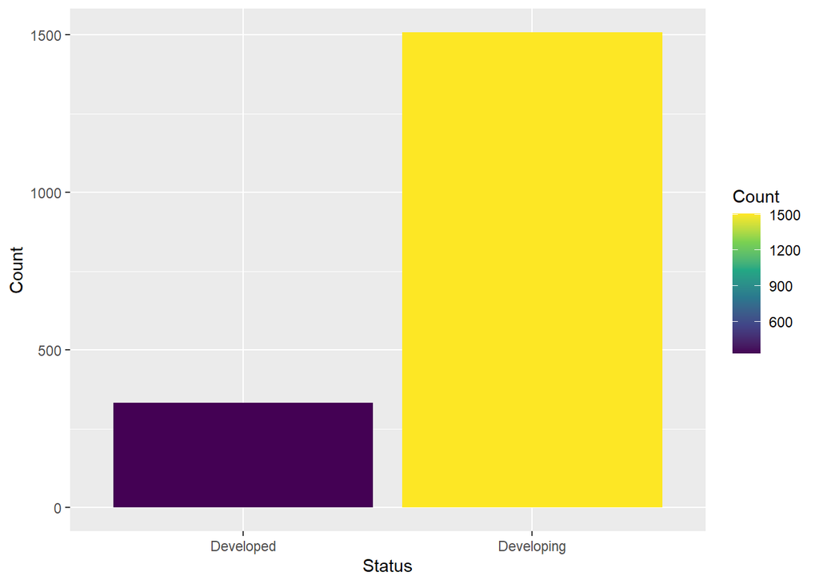

```r
train_data %>%
  count(Status) %>%
  rename(Count = n) %>%
  ggplot(aes(x=Status, y=Count)) +
  geom_histogram(stat="identity", aes(fill=Count)) +
  scale_fill_viridis_c()
```

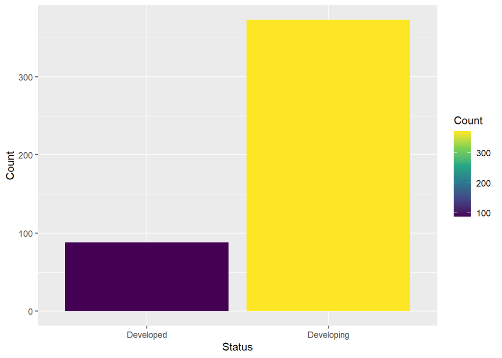

```r
test_data %>%
  count(Status) %>%
  rename(Count = n) %>%
  ggplot(aes(x=Status, y=Count)) +
  geom_histogram(stat="identity", aes(fill=Count)) +
  scale_fill_viridis_c()
```

# Experimenty

## Classification:

### Hypotézy, ktoré sa nám zdajú zaujímavé:

#### H0 1. GDP a Schooling nesuvisia s tým, či je krajina rozvojová alebo rozvinutá.

#### H0 1. GDP a percentage expenditure nesuvisia s tým, či je krajina rozvojová alebo rozvinutá.

Podľa korelácie z EDA vybraté prediktory **GDP a percentage expenditure** by mali súvisieť s **rozvojovým statusom krajiny**:

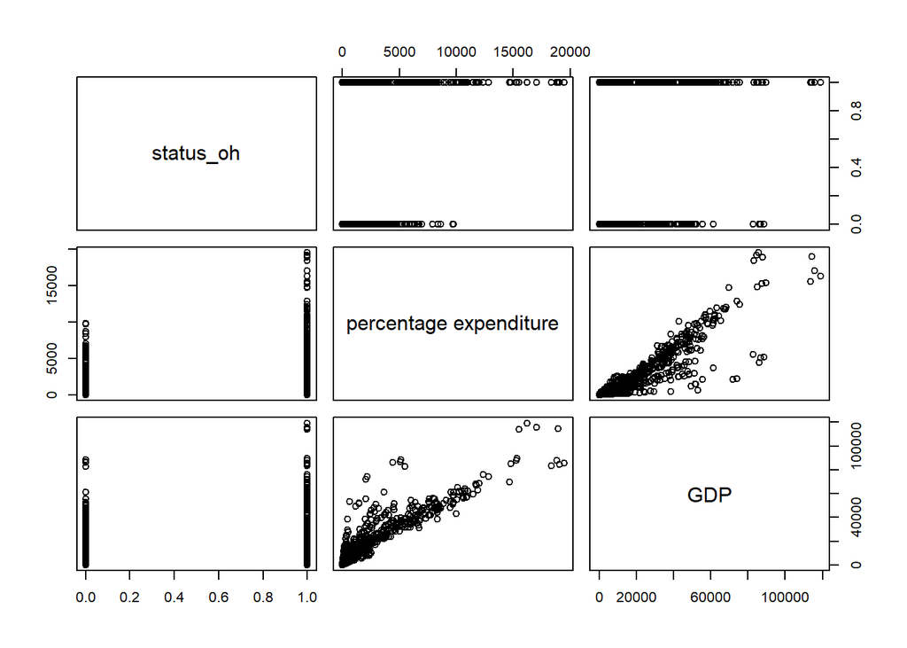

```r
data %$% pairs( status_oh ~  `percentage expenditure` + GDP)
```

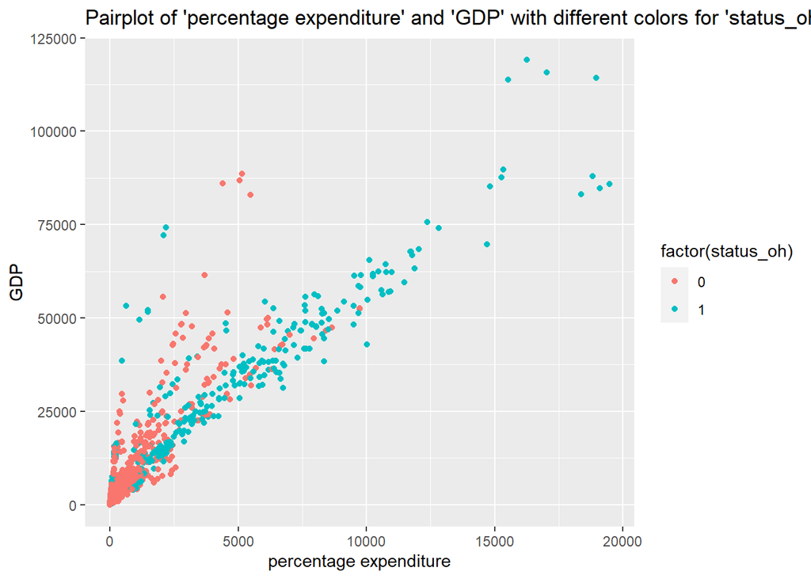

```r
ggplot(data, aes(x = `percentage expenditure`, y = GDP, color = factor(status_oh))) +
  geom_point() +
  labs(title = "Pairplot of 'percentage expenditure' and 'GDP' with different colors for 'status_oh'",
       x = "percentage expenditure", y = "GDP")
```

Podľa pairplotu z EDA vybraté prediktory **GDP a Schooling** by mali súvisieť s **rozvojovým statusom krajiny**:

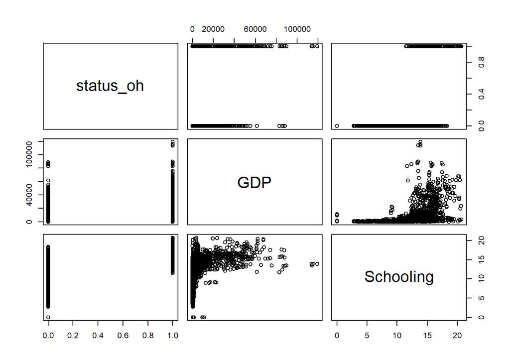

```r
data %$% pairs( status_oh ~  GDP + Schooling)
```

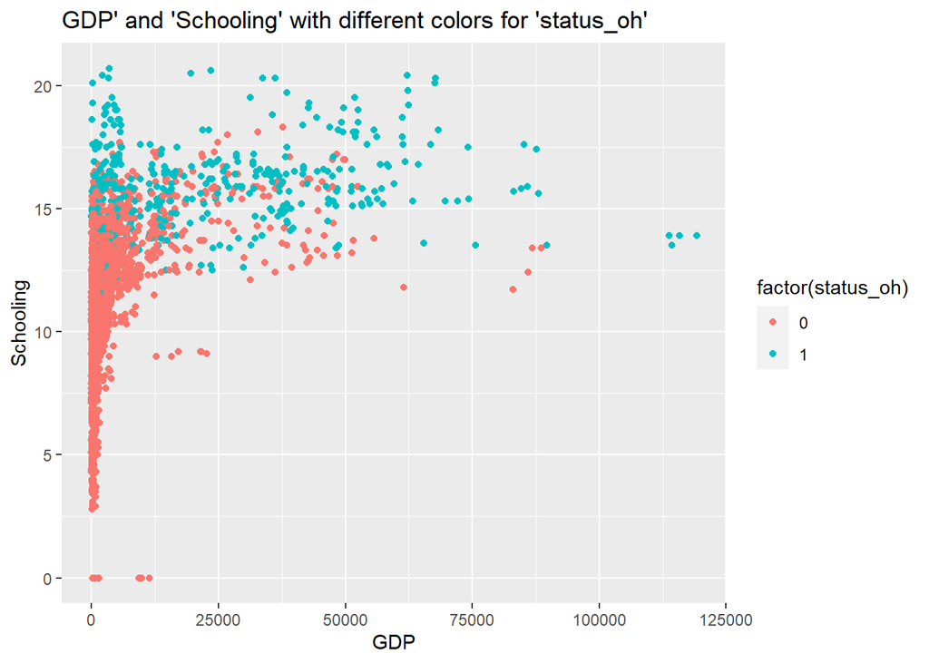

```r
ggplot(data, aes(x = GDP, y = Schooling, color = factor(status_oh))) +
  geom_point() +
  labs(title = "GDP' and 'Schooling' with different colors for 'status_oh'",
       x = "GDP", y = "Schooling")
```

zlogaritmová GDP:

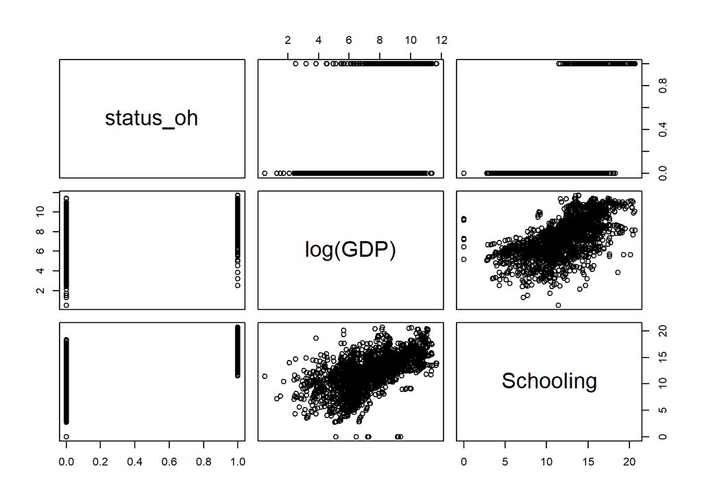

```r
data %$% pairs( status_oh ~  log(GDP) + Schooling)
```

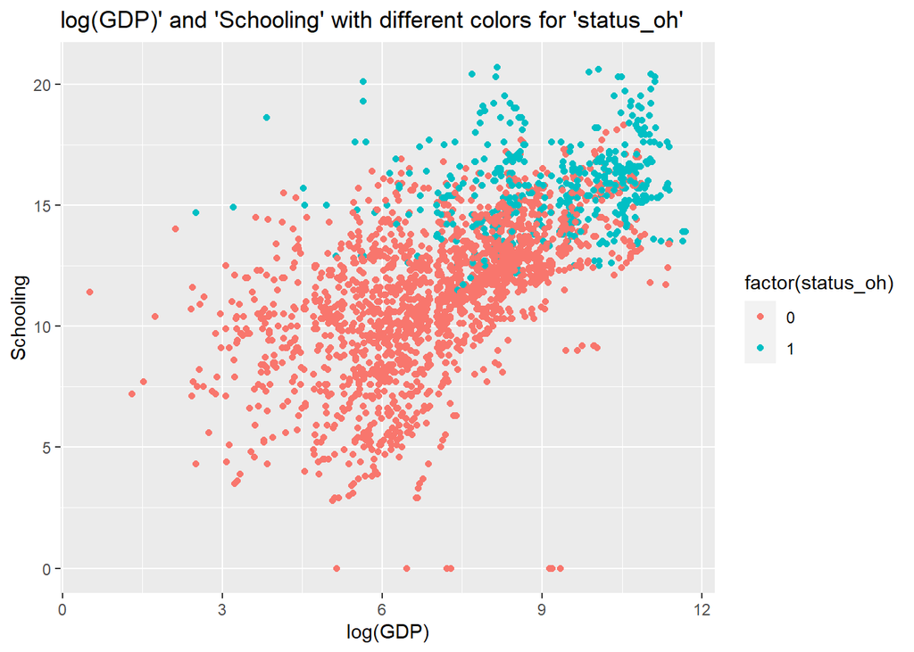

```r
ggplot(data, aes(x = log(GDP), y = Schooling, color = factor(status_oh))) +
  geom_point() +
  labs(title = "log(GDP)' and 'Schooling' with different colors for 'status_oh'",
       x = "log(GDP)", y = "Schooling")
```

### 1. experiment: Náš **response** variable bude **“status_oh”** a ostatné stĺpce **(GDP, Schooling)** budú **prediktory**.

```r
# model
model = glm(status_oh ~ GDP + Schooling, data = train_data)
summary(model)
```

```
##
## Call:
## glm(formula = status_oh ~ GDP + Schooling, data = train_data)
##
## Coefficients:
##               Estimate Std. Error t value Pr(>|t|)
## (Intercept) -4.267e-01  2.837e-02  -15.04   <2e-16 ***
## GDP          8.572e-06  5.534e-07   15.49   <2e-16 ***
## Schooling    4.488e-02  2.396e-03   18.73   <2e-16 ***
## ---
## Signif. codes:  0 '***' 0.001 '**' 0.01 '*' 0.05 '.' 0.1 ' ' 1
##
## (Dispersion parameter for gaussian family taken to be 0.09387658)
##
##     Null deviance: 272.10  on 1839  degrees of freedom
## Residual deviance: 172.45  on 1837  degrees of freedom
## AIC: 873.67
##
## Number of Fisher Scoring iterations: 2
```

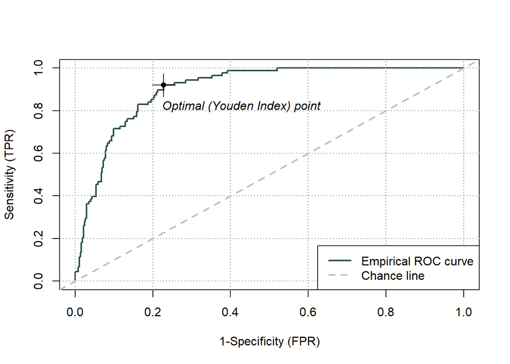

```r
predictions <- predict(model, test_data)

actual <- test_data$status_oh

# výpočet cut off hodnoty, ktorý naznačuje optimálny bod pre prahovu hodnotu, ktorá rozdeľuje predikcie na pozitívne a negatívne, čiže rozvojovú a rozvinutú krajinu.

roc = rocit(predictions, actual)
plot(roc)
```

```r
cutoff_index <- which.max(roc$TPR + (1 - roc$FPR) - 1)
optimal_cutoff <- roc$Cutoff[cutoff_index]
optimal_cutoff
```

```
## [1] 0.2165983
```

```r
predicted_class <- ifelse(predictions >= optimal_cutoff, 1, 0)

# confussion matrix
caret::confusionMatrix(as.factor(predicted_class), as.factor(actual), positive = "1")
```

```
## Confusion Matrix and Statistics
##
##           Reference
## Prediction   0   1
##          0 288   7
##          1  85  81
##
##                Accuracy : 0.8004
##                  95% CI : (0.761, 0.836)
##     No Information Rate : 0.8091
##     P-Value [Acc > NIR] : 0.7061
##
##                   Kappa : 0.5174
##
##  Mcnemar's Test P-Value : 9.923e-16
##
##             Sensitivity : 0.9205
##             Specificity : 0.7721
##          Pos Pred Value : 0.4880
##          Neg Pred Value : 0.9763
##              Prevalence : 0.1909
##          Detection Rate : 0.1757
##    Detection Prevalence : 0.3601
##       Balanced Accuracy : 0.8463
##
##        'Positive' Class : 1
##
```

Celkovo model naznačuje, že **GDP a školstvo** sú **významnými prediktormi rozvojového statusu krajiny**, pričom **vyššie GDP a úroveň školstva sú spojené s vyššou pravdepodobnosťou byť rozvinutou krajinou**. H0 zamietame. Spravili sme cross tabulaciu a z confusion matrix vidíme, že náš model má **80,04%** presnosť.

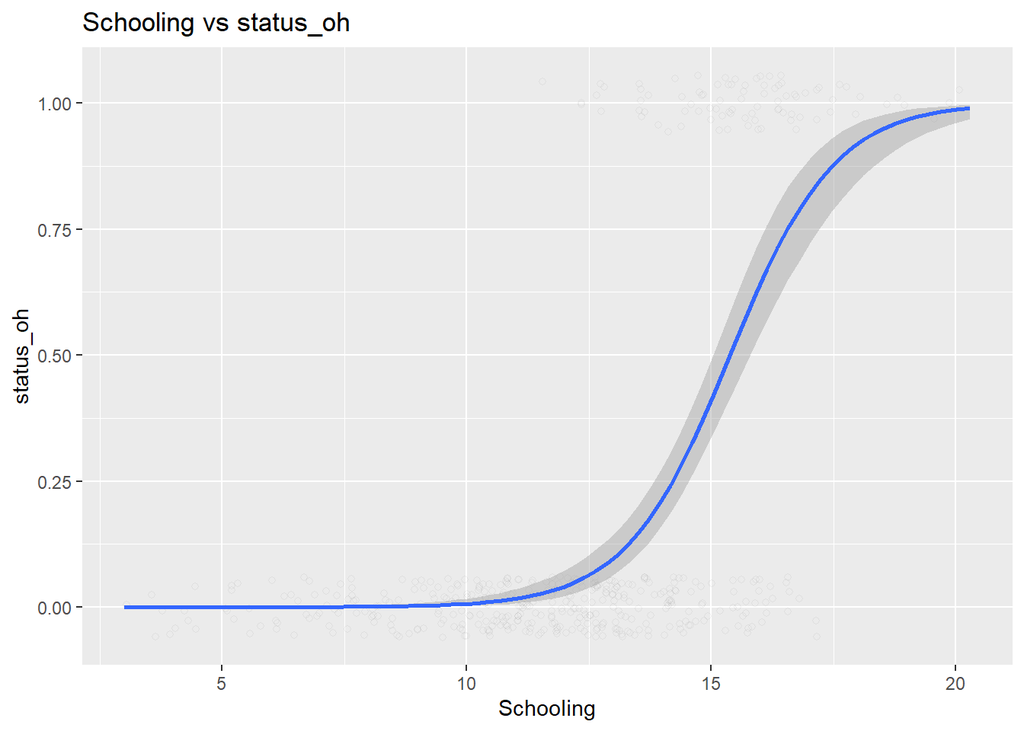

```r
test_data %>%
  ggplot(., aes(x = Schooling, y = status_oh)) +  # Specify X and Y variables
  geom_point(position = position_jitter(width = 0.3, height = 0.06),
             alpha = 0.05,
             shape = 1,
             size = 1.5) +
  stat_smooth(method = glm, method.args = list(family = binomial)) +
  ggtitle("Schooling vs status_oh")
```

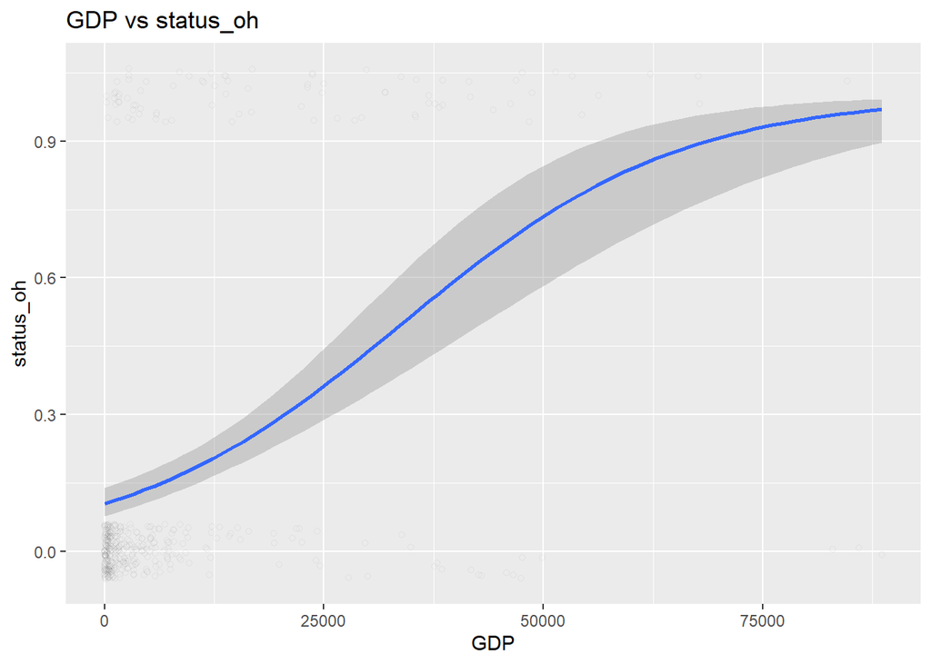

```r
test_data %>%
  ggplot(., aes(x = GDP, y = status_oh)) +  # Specify X and Y variables
  geom_point(position = position_jitter(width = 0.3, height = 0.06),
             alpha = 0.05,
             shape = 1,
             size = 1.5) +
  stat_smooth(method = glm, method.args = list(family = binomial)) +
  ggtitle("GDP vs status_oh")
```

Schooling viac vplýva na status krajiny (rozvinutá/nerozvinutá) ako GDP z grafu pre logistickú funkciu, čo nám nakoniec hovorí aj samotný model.

# Radial SVM metóda

```r
library(e1071)

# Model
svm_model <- svm(status_oh ~ GDP + Schooling, data = train_data, kernel = "radial")
summary(svm_model)
```

```
##
## Call:
## svm(formula = status_oh ~ GDP + Schooling, data = train_data, kernel = "radial")
##
##
## Parameters:
##    SVM-Type:  eps-regression
##  SVM-Kernel:  radial
##        cost:  1
##       gamma:  0.5
##     epsilon:  0.1
##
##
## Number of Support Vectors:  513
```

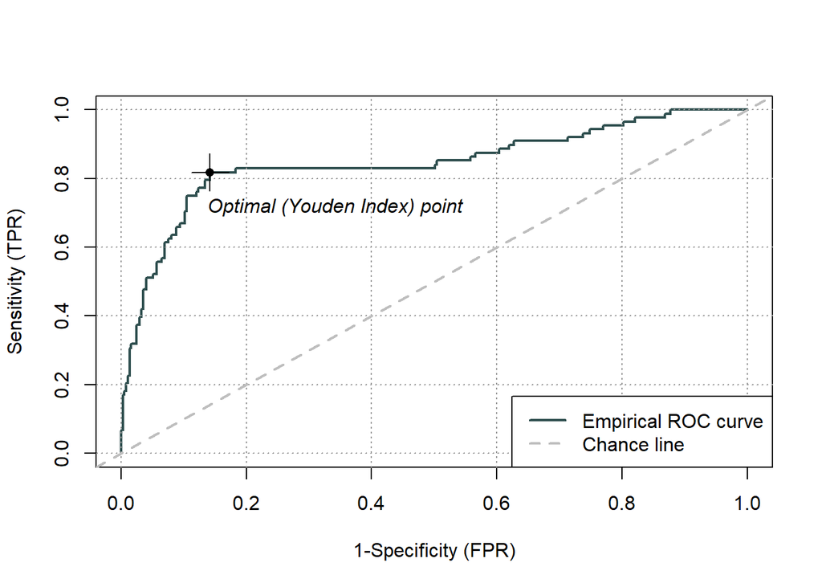

```r
# Predictions
svm_predictions <- predict(svm_model, test_data)

actual <- test_data$status_oh
roc_svm_rad = rocit(svm_predictions, actual)
plot(roc_svm_rad)
```

```r
cutoff_index <- which.max(roc_svm_rad$TPR + (1 - roc_svm_rad$FPR) - 1)
optimal_cutoff <- roc_svm_rad$Cutoff[cutoff_index]
optimal_cutoff
```

```
## [1] 0.0555859
```

```r
predicted_class_svm_rad <- ifelse(svm_predictions >= optimal_cutoff, 1, 0)

# Confusion matrix
confusionMatrix(as.factor(predicted_class_svm_rad), as.factor(test_data$status_oh))
```

```
## Confusion Matrix and Statistics
##
##           Reference
## Prediction   0   1
##          0 320  16
##          1  53  72
##
##                Accuracy : 0.8503
##                  95% CI : (0.8144, 0.8816)
##     No Information Rate : 0.8091
##     P-Value [Acc > NIR] : 0.01239
##
##                   Kappa : 0.5825
##
##  Mcnemar's Test P-Value : 1.465e-05
##
##             Sensitivity : 0.8579
##             Specificity : 0.8182
##          Pos Pred Value : 0.9524
##          Neg Pred Value : 0.5760
##              Prevalence : 0.8091
##          Detection Rate : 0.6941
##    Detection Prevalence : 0.7289
##       Balanced Accuracy : 0.8380
##
##        'Positive' Class : 0
##
```

Accuracy je 85,03%. H0 zamietame. Hodnota kappa 0.5825, čo naznačuje strednú až dobrú zhodu medzi pozorovaniami a predpovedaniami modelu. eps-regression - model sa snaží predpovedať spojitú premennú namiesto klasifikácie do dvoch tried, kedže nemáme kategorickú premennú.

# Linear SVM metóda

```r
# Model
svm_model <- svm(status_oh ~ GDP + Schooling, data = train_data, kernel = "linear")
summary(svm_model)
```

```
##
## Call:
## svm(formula = status_oh ~ GDP + Schooling, data = train_data, kernel = "linear")
##
##
## Parameters:
##    SVM-Type:  eps-regression
##  SVM-Kernel:  linear
##        cost:  1
##       gamma:  0.5
##     epsilon:  0.1
##
##
## Number of Support Vectors:  774
```

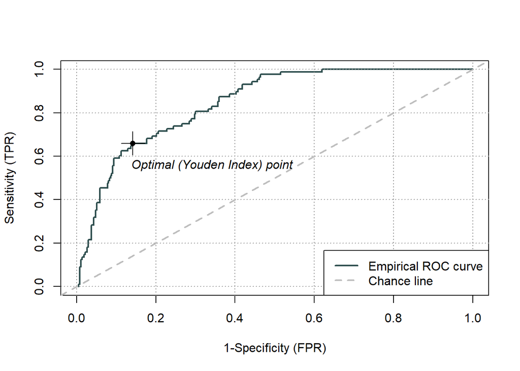

```r
# Predictions
svm_predictions <- predict(svm_model, test_data)

actual <- test_data$status_oh

roc_svm_ln = rocit(svm_predictions, actual)
plot(roc_svm_ln)
```

```r
cutoff_index <- which.max(roc_svm_ln$TPR + (1 - roc_svm_ln$FPR) - 1)
optimal_cutoff <- roc_svm_ln$Cutoff[cutoff_index]
optimal_cutoff
```

```
## [1] 0.095658
```

```r
predicted_class_svm_ln <- ifelse(svm_predictions >= optimal_cutoff, 1, 0)

# Confusion matrix
confusionMatrix(as.factor(predicted_class_svm_ln), as.factor(test_data$status_oh))
```

```
## Confusion Matrix and Statistics
##
##           Reference
## Prediction   0   1
##          0 320  30
##          1  53  58
##
##                Accuracy : 0.82
##                  95% CI : (0.7818, 0.854)
##     No Information Rate : 0.8091
##     P-Value [Acc > NIR] : 0.29999
##
##                   Kappa : 0.4701
##
##  Mcnemar's Test P-Value : 0.01574
##
##             Sensitivity : 0.8579
##             Specificity : 0.6591
##          Pos Pred Value : 0.9143
##          Neg Pred Value : 0.5225
##              Prevalence : 0.8091
##          Detection Rate : 0.6941
##    Detection Prevalence : 0.7592
##       Balanced Accuracy : 0.7585
##
##        'Positive' Class : 0
##
```

Accuracy je 82%. H0 zamietame. eps-regression - model sa snaží predpovedať spojitú premennú namiesto klasifikácie do dvoch tried, kedže nemáme kategorickú premennú.

# Naive Bayes metóda

```r
# Model
nb_model <- naiveBayes(status_oh ~ GDP + Schooling, data = train_data)
nb_model
```

```
##
## Naive Bayes Classifier for Discrete Predictors
##
## Call:
## naiveBayes.default(x = X, y = Y, laplace = laplace)
##
## A-priori probabilities:
## Y
##         0         1
## 0.8195652 0.1804348
##
## Conditional probabilities:
##    GDP
## Y        [,1]      [,2]
##   0  4040.071  8053.067
##   1 22614.937 24037.282
##
##    Schooling
## Y       [,1]     [,2]
##   0 11.28442 3.003310
##   1 15.89669 1.773424
```

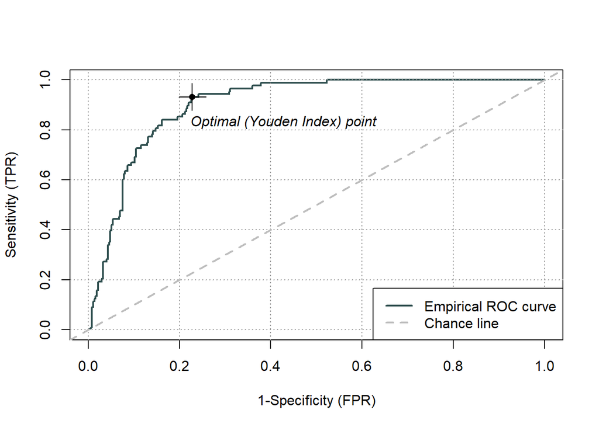

```r
# Predictions
nb_predictions <- predict(nb_model, newdata = test_data, type = "raw")

actual <- test_data$status_oh

roc_nb = rocit(nb_predictions[, 2], actual)
plot(roc_nb)
```

```r
cutoff_index <- which.max(roc_nb$TPR - roc_nb$FPR)
optimal_cutoff <- roc_nb$Cutoff[cutoff_index]

predicted_class_nb <- ifelse(nb_predictions[, 2] >= optimal_cutoff, 1, 0)

confusionMatrix(as.factor(predicted_class_nb), as.factor(test_data$status_oh))
```

```
## Confusion Matrix and Statistics
##
##           Reference
## Prediction   0   1
##          0 288   6
##          1  85  82
##
##                Accuracy : 0.8026
##                  95% CI : (0.7633, 0.838)
##     No Information Rate : 0.8091
##     P-Value [Acc > NIR] : 0.6645
##
##                   Kappa : 0.5242
##
##  Mcnemar's Test P-Value : 2.919e-16
##
##             Sensitivity : 0.7721
##             Specificity : 0.9318
##          Pos Pred Value : 0.9796
##          Neg Pred Value : 0.4910
##              Prevalence : 0.8091
##          Detection Rate : 0.6247
##    Detection Prevalence : 0.6377
##       Balanced Accuracy : 0.8520
##
##        'Positive' Class : 0
##
```

Accuracy je 80,26%. H0 zamietame. mean - ([,1]) a standard deviation - ([,2]) pre každú triedu (0 and 1).

# Random Forest metóda

```r
#install.packages("randomForest") # uncomment if you don't have the package installed
library(randomForest)

# Model
rf_model <- randomForest(status_oh ~ GDP + Schooling, data = train_data)
rf_model
```

```
##
## Call:
##  randomForest(formula = status_oh ~ GDP + Schooling, data = train_data)
##                Type of random forest: regression
##                      Number of trees: 500
## No. of variables tried at each split: 1
##
##           Mean of squared residuals: 0.08067882
##                     % Var explained: 45.44
```

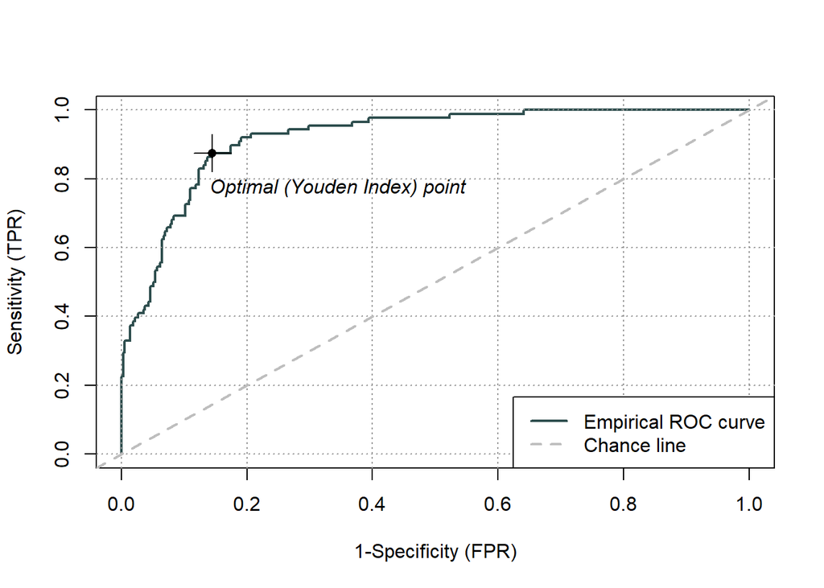

```r
# Predictions
rf_predictions <- predict(rf_model, test_data)

actual <- test_data$status_oh
roc_random_forrest = rocit(rf_predictions, actual)
plot(roc_random_forrest)
```

```r
cutoff_index <- which.max(roc_random_forrest$TPR + (1 - roc_random_forrest$FPR) - 1)
optimal_cutoff <- roc_random_forrest$Cutoff[cutoff_index]
optimal_cutoff
```

```
## [1] 0.2139033
```

```r
predicted_class_randomm_forrest <- ifelse(rf_predictions >= optimal_cutoff, 1, 0)


confusionMatrix(as.factor(predicted_class_randomm_forrest), as.factor(test_data$status_oh))
```

```
## Confusion Matrix and Statistics
##
##           Reference
## Prediction   0   1
##          0 319  11
##          1  54  77
##
##                Accuracy : 0.859
##                  95% CI : (0.8238, 0.8895)
##     No Information Rate : 0.8091
##     P-Value [Acc > NIR] : 0.002959
##
##                   Kappa : 0.6154
##
##  Mcnemar's Test P-Value : 1.894e-07
##
##             Sensitivity : 0.8552
##             Specificity : 0.8750
##          Pos Pred Value : 0.9667
##          Neg Pred Value : 0.5878
##              Prevalence : 0.8091
##          Detection Rate : 0.6920
##    Detection Prevalence : 0.7158
##       Balanced Accuracy : 0.8651
##
##        'Positive' Class : 0
##
```

Accuracy je 85,9%. H0 zamietame.

# LDA metóda

```r
library(MASS)

# Model
lda_model <- lda(status_oh ~ GDP + Schooling, data = train_data)
lda_model
```

```
## Call:
## lda(status_oh ~ GDP + Schooling, data = train_data)
##
## Prior probabilities of groups:
##         0         1
## 0.8195652 0.1804348
##
## Group means:
##         GDP Schooling
## 0  4040.071  11.28442
## 1 22614.937  15.89669
##
## Coefficients of linear discriminants:
##                    LD1
## GDP       4.624647e-05
## Schooling 2.420946e-01
```

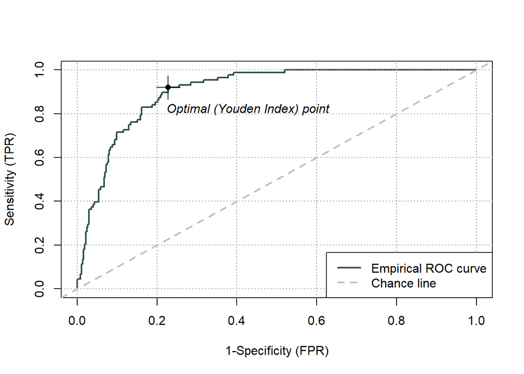

```r
# Predictions

lda_predictions <- predict(lda_model, newdata = test_data)$posterior[, "1"]

actual <- test_data$status_oh

roc_lda = rocit(lda_predictions, actual)
plot(roc_lda)
```

```r
cutoff_index <- which.max(roc_lda$TPR - roc_lda$FPR)
optimal_cutoff <- roc_lda$Cutoff[cutoff_index]

predicted_class_lda <- ifelse(lda_predictions >= optimal_cutoff, 1, 0)

confusionMatrix(as.factor(predicted_class_lda), as.factor(test_data$status_oh))
```

```
## Confusion Matrix and Statistics
##
##           Reference
## Prediction   0   1
##          0 288   7
##          1  85  81
##
##                Accuracy : 0.8004
##                  95% CI : (0.761, 0.836)
##     No Information Rate : 0.8091
##     P-Value [Acc > NIR] : 0.7061
##
##                   Kappa : 0.5174
##
##  Mcnemar's Test P-Value : 9.923e-16
##
##             Sensitivity : 0.7721
##             Specificity : 0.9205
##          Pos Pred Value : 0.9763
##          Neg Pred Value : 0.4880
##              Prevalence : 0.8091
##          Detection Rate : 0.6247
##    Detection Prevalence : 0.6399
##       Balanced Accuracy : 0.8463
##
##        'Positive' Class : 0
##
```

Accuracy je 80,04%. H0 zamietame.

## Model performance parameters v 1 tabuľke pre 1. experiment:

```r
library(pROC)

test_data$status_oh <- as.factor(test_data$status_oh)

# Calculate performance metrics
data.frame(
  Model = c("GLM","LDA", "SVM-linear","SVM-radial", "Naive Bayes", "Random Forrest"),
  Accuracy = c(
    confusionMatrix(as.factor(predicted_class), test_data$status_oh)$overall["Accuracy"],
    confusionMatrix(as.factor(predicted_class_lda), test_data$status_oh)$overall["Accuracy"],
    confusionMatrix(as.factor(predicted_class_svm_ln), test_data$status_oh)$overall["Accuracy"],
    confusionMatrix(as.factor(predicted_class_svm_rad), test_data$status_oh)$overall["Accuracy"],
    confusionMatrix(as.factor(predicted_class_nb), test_data$status_oh)$overall["Accuracy"],
    confusionMatrix(as.factor(predicted_class_randomm_forrest), test_data$status_oh)$overall["Accuracy"]
  ),
  Sensitivity = c(
    confusionMatrix(as.factor(predicted_class), test_data$status_oh)$byClass["Sensitivity"],
    confusionMatrix(as.factor(predicted_class_lda), test_data$status_oh)$byClass["Sensitivity"],
    confusionMatrix(as.factor(predicted_class_svm_ln), test_data$status_oh)$byClass["Sensitivity"],
    confusionMatrix(as.factor(predicted_class_svm_rad), test_data$status_oh)$byClass["Sensitivity"],
    confusionMatrix(as.factor(predicted_class_nb), test_data$status_oh)$byClass["Sensitivity"],
    confusionMatrix(as.factor(predicted_class_randomm_forrest), test_data$status_oh)$byClass["Sensitivity"]
  ),
  Specificity = c(
    confusionMatrix(as.factor(predicted_class), test_data$status_oh)$byClass["Specificity"],
    confusionMatrix(as.factor(predicted_class_lda), test_data$status_oh)$byClass["Specificity"],
    confusionMatrix(as.factor(predicted_class_svm_ln), test_data$status_oh)$byClass["Specificity"],
    confusionMatrix(as.factor(predicted_class_svm_rad), test_data$status_oh)$byClass["Specificity"],
    confusionMatrix(as.factor(predicted_class_nb), test_data$status_oh)$byClass["Specificity"],
    confusionMatrix(as.factor(predicted_class_randomm_forrest), test_data$status_oh)$byClass["Specificity"]
  ),
  F1_Score = c(
    confusionMatrix(as.factor(predicted_class), test_data$status_oh)$byClass["F1"],
    confusionMatrix(as.factor(predicted_class_lda), test_data$status_oh)$byClass["F1"],
    confusionMatrix(as.factor(predicted_class_svm_ln), test_data$status_oh)$byClass["F1"],
    confusionMatrix(as.factor(predicted_class_svm_rad), test_data$status_oh)$byClass["F1"],
    confusionMatrix(as.factor(predicted_class_nb), test_data$status_oh)$byClass["F1"],
    confusionMatrix(as.factor(predicted_class_randomm_forrest), test_data$status_oh)$byClass["F1"]
  ),
  AUC_ROC = c(
    roc(test_data$status_oh, as.numeric(predicted_class))$auc,
    roc(test_data$status_oh, as.numeric(predicted_class_lda))$auc,
    roc(test_data$status_oh, as.numeric(predicted_class_svm_ln))$auc,
    roc(test_data$status_oh, as.numeric(predicted_class_svm_rad))$auc,
    roc(test_data$status_oh, as.numeric(predicted_class_nb))$auc,
    roc(test_data$status_oh, as.numeric(predicted_class_randomm_forrest))$auc
  )
)
```

```
##            Model  Accuracy Sensitivity Specificity  F1_Score   AUC_ROC
## 1            GLM 0.8004338   0.7721180   0.9204545 0.8622754 0.8462863
## 2            LDA 0.8004338   0.7721180   0.9204545 0.8622754 0.8462863
## 3     SVM-linear 0.8199566   0.8579088   0.6590909 0.8852006 0.7584999
## 4     SVM-radial 0.8503254   0.8579088   0.8181818 0.9026798 0.8380453
## 5    Naive Bayes 0.8026030   0.7721180   0.9318182 0.8635682 0.8519681
## 6 Random Forrest 0.8590022   0.8552279   0.8750000 0.9075391 0.8651139
```

Model SVM-radial má spolu s SVM-linear najvyššiu citlivosť (0,8579), čo naznačuje, že efektívne identifikuje pozitívne prípady. Model Naive Bayes má najvyššiu špecificitu (0,9318), čo naznačuje, že efektívne identifikuje negatívne prípady, naopak SVM-linear malo najnižšiu a to výrazne. SVM-linear malo ešte horšie výsledky pri metrike AUCROC. Metrika F1 bola približne rovnaká pre všetky metódy.

### 2. experiment: podobne ako 1.experiment, no máme zlogaritmovaný GDP

```r
train_data %<>%
  mutate(log_GDP = log(GDP))
test_data %<>%
  mutate(log_GDP = log(GDP))


# model
model = glm(status_oh ~ log_GDP + Schooling, data = train_data)
summary(model)
```

```
##
## Call:
## glm(formula = status_oh ~ log_GDP + Schooling, data = train_data)
##
## Coefficients:
##              Estimate Std. Error t value Pr(>|t|)
## (Intercept) -0.681812   0.032446  -21.01  < 2e-16 ***
## log_GDP      0.036732   0.004991    7.36 2.76e-13 ***
## Schooling    0.048661   0.002841   17.13  < 2e-16 ***
## ---
## Signif. codes:  0 '***' 0.001 '**' 0.01 '*' 0.05 '.' 0.1 ' ' 1
##
## (Dispersion parameter for gaussian family taken to be 0.1030977)
##
##     Null deviance: 272.10  on 1839  degrees of freedom
## Residual deviance: 189.39  on 1837  degrees of freedom
## AIC: 1046.1
##
## Number of Fisher Scoring iterations: 2
```

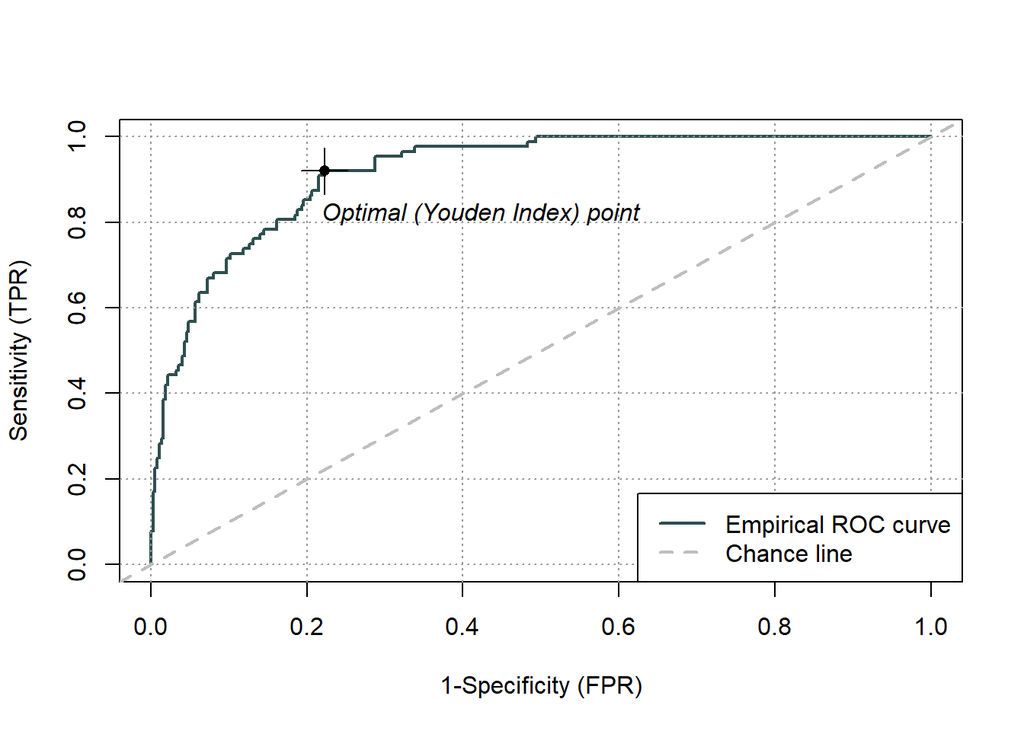

```r
predictions <- predict(model, test_data)

actual <- test_data$status_oh

# výpočet cut off hodnoty, ktorý naznačuje optimálny bod pre prahovu hodnotu, ktorá rozdeľuje predikcie na pozitívne a negatívne, čiže rozvojovú a rozvinutú krajinu.

roc = rocit(predictions, actual)
plot(roc)
```

```r
cutoff_index <- which.max(roc$TPR + (1 - roc$FPR) - 1)
optimal_cutoff <- roc$Cutoff[cutoff_index]
optimal_cutoff
```

```
## [1] 0.2720118
```

```r
predicted_class <- ifelse(predictions >= optimal_cutoff, 1, 0)

# confussion matrix
caret::confusionMatrix(as.factor(predicted_class), as.factor(actual), positive = "1")
```

```
## Confusion Matrix and Statistics
##
##           Reference
## Prediction   0   1
##          0 290   7
##          1  83  81
##
##                Accuracy : 0.8048
##                  95% CI : (0.7656, 0.84)
##     No Information Rate : 0.8091
##     P-Value [Acc > NIR] : 0.6207
##
##                   Kappa : 0.5248
##
##  Mcnemar's Test P-Value : 2.664e-15
##
##             Sensitivity : 0.9205
##             Specificity : 0.7775
##          Pos Pred Value : 0.4939
##          Neg Pred Value : 0.9764
##              Prevalence : 0.1909
##          Detection Rate : 0.1757
##    Detection Prevalence : 0.3557
##       Balanced Accuracy : 0.8490
##
##        'Positive' Class : 1
##
```

Accuracy: 80,48%. H0 zamietame.

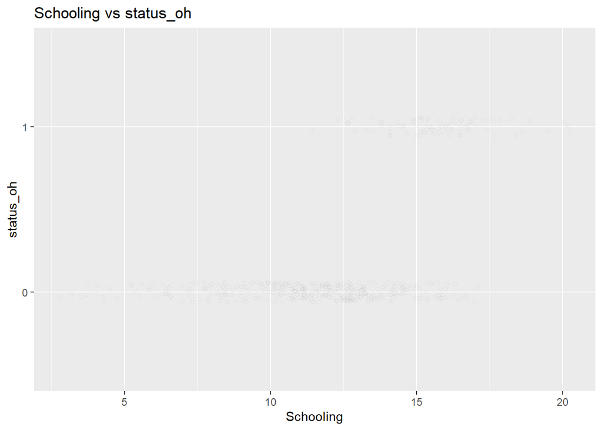

```r
test_data %>%
  ggplot(., aes(x = Schooling, y = status_oh)) +  # Specify X and Y variables
  geom_point(position = position_jitter(width = 0.3, height = 0.06),
             alpha = 0.05,
             shape = 1,
             size = 1.5) +
  stat_smooth(method = glm, method.args = list(family = binomial)) +
  ggtitle("Schooling vs status_oh")
```

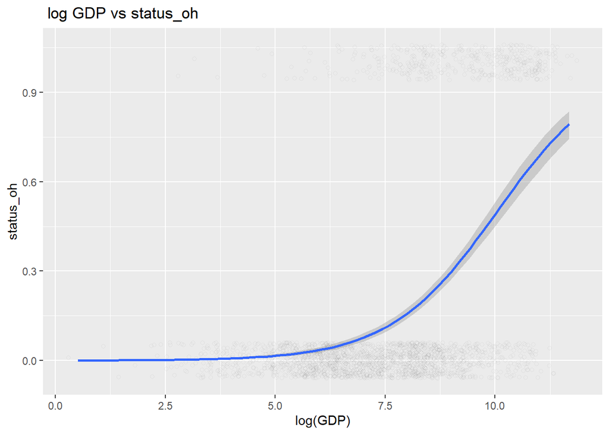

```r
data %>%
  ggplot(., aes(x = log(GDP), y = status_oh)) +  # Specify X and Y variables
  geom_point(position = position_jitter(width = 0.3, height = 0.06),
             alpha = 0.05,
             shape = 1,
             size = 1.5) +
  stat_smooth(method = glm, method.args = list(family = binomial)) +
  ggtitle(" log GDP vs status_oh")
```

# Radial SVM metóda

```r
library(e1071)

# Model
svm_model <- svm(status_oh ~ log_GDP + Schooling, data = train_data, kernel = "radial")
summary(svm_model)
```

```
##
## Call:
## svm(formula = status_oh ~ log_GDP + Schooling, data = train_data,
##     kernel = "radial")
##
##
## Parameters:
##    SVM-Type:  eps-regression
##  SVM-Kernel:  radial
##        cost:  1
##       gamma:  0.5
##     epsilon:  0.1
##
##
## Number of Support Vectors:  568
```

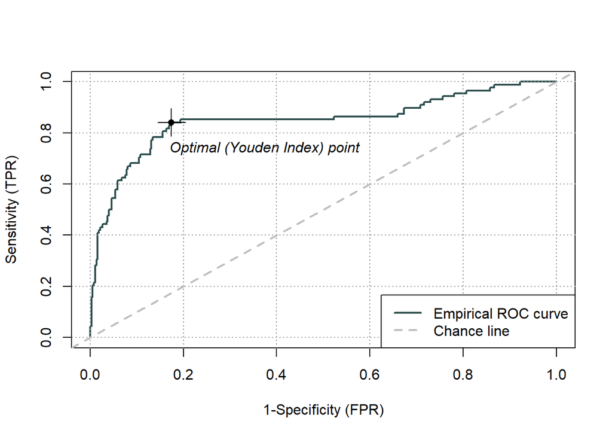

```r
# Predictions
svm_predictions <- predict(svm_model, test_data)

actual <- test_data$status_oh
roc_svm_rad = rocit(svm_predictions, actual)
plot(roc_svm_rad)
```

```r
cutoff_index <- which.max(roc_svm_rad$TPR + (1 - roc_svm_rad$FPR) - 1)
optimal_cutoff <- roc_svm_rad$Cutoff[cutoff_index]
optimal_cutoff
```

```
## [1] 0.04739611
```

```r
predicted_class_svm_rad <- ifelse(svm_predictions >= optimal_cutoff, 1, 0)

# Confusion matrix
confusionMatrix(as.factor(predicted_class_svm_rad), as.factor(test_data$status_oh))
```

```
## Confusion Matrix and Statistics
##
##           Reference
## Prediction   0   1
##          0 308  14
##          1  65  74
##
##                Accuracy : 0.8286
##                  95% CI : (0.7911, 0.8619)
##     No Information Rate : 0.8091
##     P-Value [Acc > NIR] : 0.1568
##
##                   Kappa : 0.5458
##
##  Mcnemar's Test P-Value : 1.85e-08
##
##             Sensitivity : 0.8257
##             Specificity : 0.8409
##          Pos Pred Value : 0.9565
##          Neg Pred Value : 0.5324
##              Prevalence : 0.8091
##          Detection Rate : 0.6681
##    Detection Prevalence : 0.6985
##       Balanced Accuracy : 0.8333
##
##        'Positive' Class : 0
##
```

Accuracy: 82,86%. H0 zamietame. eps-regression - model sa snaží predpovedať spojitú premennú namiesto klasifikácie do dvoch tried, kedže nemáme kategorickú premennú.

# Linear SVM metóda

```r
# Model
svm_model <- svm(status_oh ~ log_GDP + Schooling, data = train_data, kernel = "linear")
summary(svm_model)
```

```
##
## Call:
## svm(formula = status_oh ~ log_GDP + Schooling, data = train_data,
##     kernel = "linear")
##
##
## Parameters:
##    SVM-Type:  eps-regression
##  SVM-Kernel:  linear
##        cost:  1
##       gamma:  0.5
##     epsilon:  0.1
##
##
## Number of Support Vectors:  738
```

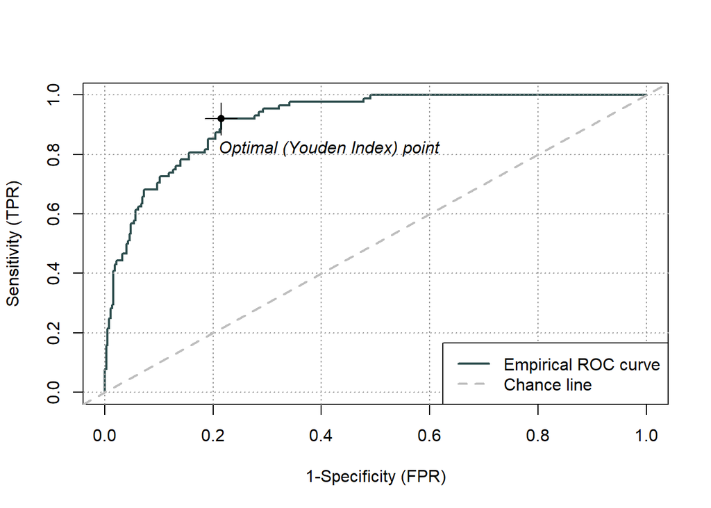

```r
# Predictions
svm_predictions <- predict(svm_model, test_data)

actual <- test_data$status_oh

roc_svm_ln = rocit(svm_predictions, actual)
plot(roc_svm_ln)
```

```r
cutoff_index <- which.max(roc_svm_ln$TPR + (1 - roc_svm_ln$FPR) - 1)
optimal_cutoff <- roc_svm_ln$Cutoff[cutoff_index]
optimal_cutoff
```

```
## [1] 0.0399376
```

```r
predicted_class_svm_ln <- ifelse(svm_predictions >= optimal_cutoff, 1, 0)

# Confusion matrix
confusionMatrix(as.factor(predicted_class_svm_ln), as.factor(test_data$status_oh))
```

```
## Confusion Matrix and Statistics
##
##           Reference
## Prediction   0   1
##          0 293   7
##          1  80  81
##
##                Accuracy : 0.8113
##                  95% CI : (0.7725, 0.846)
##     No Information Rate : 0.8091
##     P-Value [Acc > NIR] : 0.4812
##
##                   Kappa : 0.5361
##
##  Mcnemar's Test P-Value : 1.171e-14
##
##             Sensitivity : 0.7855
##             Specificity : 0.9205
##          Pos Pred Value : 0.9767
##          Neg Pred Value : 0.5031
##              Prevalence : 0.8091
##          Detection Rate : 0.6356
##    Detection Prevalence : 0.6508
##       Balanced Accuracy : 0.8530
##
##        'Positive' Class : 0
##
```

Accuracy 81,13%. H0 zamietame. eps-regression - model sa snaží predpovedať spojitú premennú namiesto klasifikácie do dvoch tried, kedže nemáme kategorickú premennú.

# Naive Bayes metóda

```r
# Model
nb_model <- naiveBayes(status_oh ~ log_GDP + Schooling, data = train_data)
nb_model
```

```
##
## Naive Bayes Classifier for Discrete Predictors
##
## Call:
## naiveBayes.default(x = X, y = Y, laplace = laplace)
##
## A-priori probabilities:
## Y
##         0         1
## 0.8195652 0.1804348
##
## Conditional probabilities:
##    log_GDP
## Y       [,1]     [,2]
##   0 7.031830 1.727523
##   1 9.196684 1.595813
##
##    Schooling
## Y       [,1]     [,2]
##   0 11.28442 3.003310
##   1 15.89669 1.773424
```

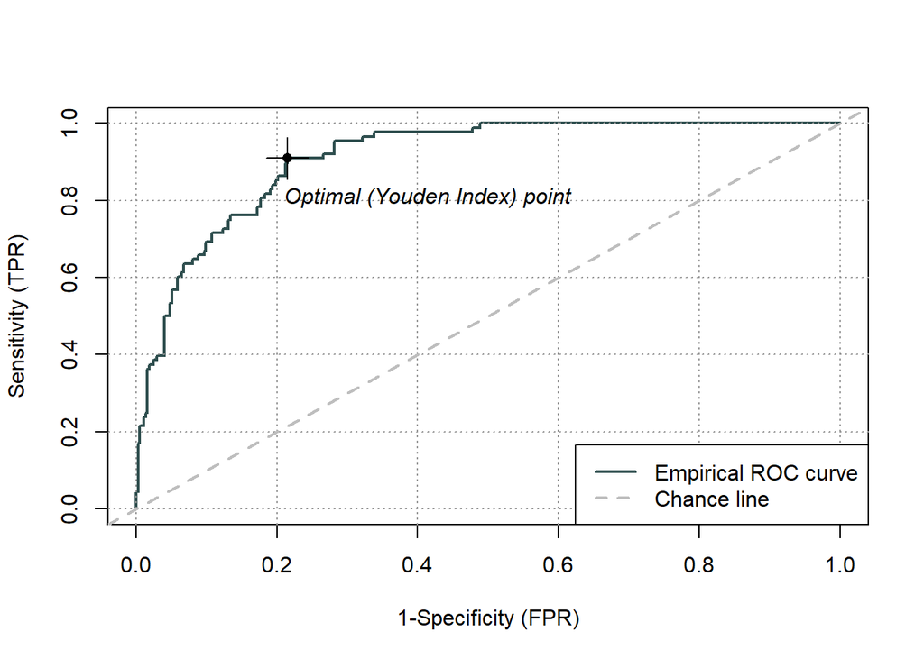

```r
# Predictions
nb_predictions <- predict(nb_model, newdata = test_data, type = "raw")

actual <- test_data$status_oh

roc_nb = rocit(nb_predictions[, 2], actual)
plot(roc_nb)
```

```r
cutoff_index <- which.max(roc_nb$TPR - roc_nb$FPR)
optimal_cutoff <- roc_nb$Cutoff[cutoff_index]

predicted_class_nb <- ifelse(nb_predictions[, 2] >= optimal_cutoff, 1, 0)

confusionMatrix(as.factor(predicted_class_nb), as.factor(test_data$status_oh))
```

```
## Confusion Matrix and Statistics
##
##           Reference
## Prediction   0   1
##          0 293   8
##          1  80  80
##
##                Accuracy : 0.8091
##                  95% CI : (0.7702, 0.844)
##     No Information Rate : 0.8091
##     P-Value [Acc > NIR] : 0.5285
##
##                   Kappa : 0.5292
##
##  Mcnemar's Test P-Value : 3.772e-14
##
##             Sensitivity : 0.7855
##             Specificity : 0.9091
##          Pos Pred Value : 0.9734
##          Neg Pred Value : 0.5000
##              Prevalence : 0.8091
##          Detection Rate : 0.6356
##    Detection Prevalence : 0.6529
##       Balanced Accuracy : 0.8473
##
##        'Positive' Class : 0
##
```

Accuracy: 80,91%. H0 zamietame. mean - ([,1]) a standard deviation - ([,2]) pre každú triedu (0 and 1).

# Random Forest metóda

```r
#install.packages("randomForest") # uncomment if you don't have the package installed
library(randomForest)

# Model
rf_model <- randomForest(status_oh ~ log_GDP + Schooling, data = train_data)
rf_model
```

```
##
## Call:
##  randomForest(formula = status_oh ~ log_GDP + Schooling, data = train_data)
##                Type of random forest: regression
##                      Number of trees: 500
## No. of variables tried at each split: 1
##
##           Mean of squared residuals: 0.08031358
##                     % Var explained: 45.69
```

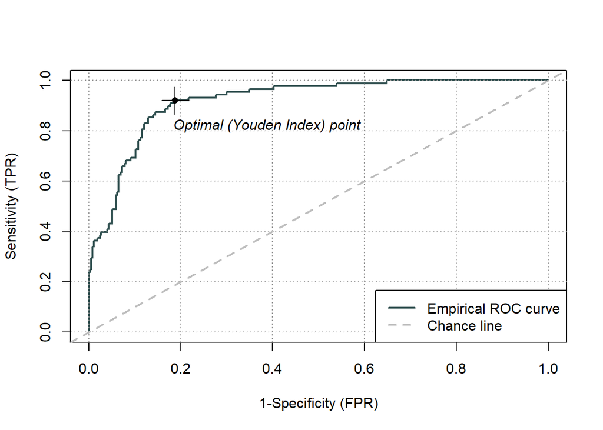

```r
# Predictions
rf_predictions <- predict(rf_model, test_data)

actual <- test_data$status_oh
roc_random_forrest = rocit(rf_predictions, actual)
plot(roc_random_forrest)
```

```r
cutoff_index <- which.max(roc_random_forrest$TPR + (1 - roc_random_forrest$FPR) - 1)
optimal_cutoff <- roc_random_forrest$Cutoff[cutoff_index]
optimal_cutoff
```

```
## [1] 0.1317556
```

```r
predicted_class_randomm_forrest <- ifelse(rf_predictions >= optimal_cutoff, 1, 0)


confusionMatrix(as.factor(predicted_class_randomm_forrest), as.factor(test_data$status_oh))
```

```
## Confusion Matrix and Statistics
##
##           Reference
## Prediction   0   1
##          0 303   7
##          1  70  81
##
##                Accuracy : 0.833
##                  95% CI : (0.7957, 0.8659)
##     No Information Rate : 0.8091
##     P-Value [Acc > NIR] : 0.1053
##
##                   Kappa : 0.5754
##
##  Mcnemar's Test P-Value : 1.6e-12
##
##             Sensitivity : 0.8123
##             Specificity : 0.9205
##          Pos Pred Value : 0.9774
##          Neg Pred Value : 0.5364
##              Prevalence : 0.8091
##          Detection Rate : 0.6573
##    Detection Prevalence : 0.6725
##       Balanced Accuracy : 0.8664
##
##        'Positive' Class : 0
##
```

Accuracy je 83,3%. H0 zamietame.

# LDA metóda

```r
# Model
lda_model <- lda(status_oh ~ log_GDP + Schooling, data = train_data)
lda_model
```

```
## Call:
## lda(status_oh ~ log_GDP + Schooling, data = train_data)
##
## Prior probabilities of groups:
##         0         1
## 0.8195652 0.1804348
##
## Group means:
##    log_GDP Schooling
## 0 7.031830  11.28442
## 1 9.196684  15.89669
##
## Coefficients of linear discriminants:
##                 LD1
## log_GDP   0.2075550
## Schooling 0.2749586
```

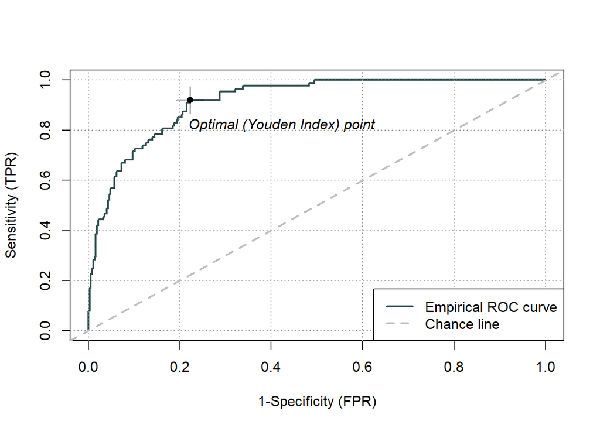

```r
# Predictions

lda_predictions <- predict(lda_model, newdata = test_data)$posterior[, "1"]

actual <- test_data$status_oh

roc_lda = rocit(lda_predictions, actual)
plot(roc_lda)
```

```r
cutoff_index <- which.max(roc_lda$TPR - roc_lda$FPR)
optimal_cutoff <- roc_lda$Cutoff[cutoff_index]

predicted_class_lda <- ifelse(lda_predictions >= optimal_cutoff, 1, 0)

confusionMatrix(as.factor(predicted_class_lda), as.factor(test_data$status_oh))
```

```
## Confusion Matrix and Statistics
##
##           Reference
## Prediction   0   1
##          0 290   7
##          1  83  81
##
##                Accuracy : 0.8048
##                  95% CI : (0.7656, 0.84)
##     No Information Rate : 0.8091
##     P-Value [Acc > NIR] : 0.6207
##
##                   Kappa : 0.5248
##
##  Mcnemar's Test P-Value : 2.664e-15
##
##             Sensitivity : 0.7775
##             Specificity : 0.9205
##          Pos Pred Value : 0.9764
##          Neg Pred Value : 0.4939
##              Prevalence : 0.8091
##          Detection Rate : 0.6291
##    Detection Prevalence : 0.6443
##       Balanced Accuracy : 0.8490
##
##        'Positive' Class : 0
##
```

Accuracy je 80,48%. H0 zamietame.

## Model performance parameters v 1 tabuľke pre 2. experiment:

```r
library(pROC)

test_data$status_oh <- as.factor(test_data$status_oh)

# Calculate performance metrics
data.frame(
  Model = c("GLM","LDA", "SVM-linear","SVM-radial", "Naive Bayes","Random Forest"),
  Accuracy = c(
    confusionMatrix(as.factor(predicted_class), test_data$status_oh)$overall["Accuracy"],
    confusionMatrix(as.factor(predicted_class_lda), test_data$status_oh)$overall["Accuracy"],
    confusionMatrix(as.factor(predicted_class_svm_ln), test_data$status_oh)$overall["Accuracy"],
    confusionMatrix(as.factor(predicted_class_svm_rad), test_data$status_oh)$overall["Accuracy"],
    confusionMatrix(as.factor(predicted_class_nb), test_data$status_oh)$overall["Accuracy"],
    confusionMatrix(as.factor(predicted_class_randomm_forrest), test_data$status_oh)$overall["Accuracy"]
  ),
  Sensitivity = c(
    confusionMatrix(as.factor(predicted_class), test_data$status_oh)$byClass["Sensitivity"],
    confusionMatrix(as.factor(predicted_class_lda), test_data$status_oh)$byClass["Sensitivity"],
    confusionMatrix(as.factor(predicted_class_svm_ln), test_data$status_oh)$byClass["Sensitivity"],
    confusionMatrix(as.factor(predicted_class_svm_rad), test_data$status_oh)$byClass["Sensitivity"],
    confusionMatrix(as.factor(predicted_class_nb), test_data$status_oh)$byClass["Sensitivity"],
    confusionMatrix(as.factor(predicted_class_randomm_forrest), test_data$status_oh)$byClass["Sensitivity"]
  ),
  Specificity = c(
    confusionMatrix(as.factor(predicted_class), test_data$status_oh)$byClass["Specificity"],
    confusionMatrix(as.factor(predicted_class_lda), test_data$status_oh)$byClass["Specificity"],
    confusionMatrix(as.factor(predicted_class_svm_ln), test_data$status_oh)$byClass["Specificity"],
    confusionMatrix(as.factor(predicted_class_svm_rad), test_data$status_oh)$byClass["Specificity"],
    confusionMatrix(as.factor(predicted_class_nb), test_data$status_oh)$byClass["Specificity"],
    confusionMatrix(as.factor(predicted_class_randomm_forrest), test_data$status_oh)$byClass["Specificity"]
  ),
  F1_Score = c(
    confusionMatrix(as.factor(predicted_class), test_data$status_oh)$byClass["F1"],
    confusionMatrix(as.factor(predicted_class_lda), test_data$status_oh)$byClass["F1"],
    confusionMatrix(as.factor(predicted_class_svm_ln), test_data$status_oh)$byClass["F1"],
    confusionMatrix(as.factor(predicted_class_svm_rad), test_data$status_oh)$byClass["F1"],
    confusionMatrix(as.factor(predicted_class_nb), test_data$status_oh)$byClass["F1"],
    confusionMatrix(as.factor(predicted_class_randomm_forrest), test_data$status_oh)$byClass["F1"]
  ),
  AUC_ROC = c(
    roc(test_data$status_oh, as.numeric(predicted_class))$auc,
    roc(test_data$status_oh, as.numeric(predicted_class_lda))$auc,
    roc(test_data$status_oh, as.numeric(predicted_class_svm_ln))$auc,
    roc(test_data$status_oh, as.numeric(predicted_class_svm_rad))$auc,
    roc(test_data$status_oh, as.numeric(predicted_class_nb))$auc,
    roc(test_data$status_oh, as.numeric(predicted_class_randomm_forrest))$auc
  )
)
```

```
##           Model  Accuracy Sensitivity Specificity  F1_Score   AUC_ROC
## 1           GLM 0.8047722   0.7774799   0.9204545 0.8656716 0.8489672
## 2           LDA 0.8047722   0.7774799   0.9204545 0.8656716 0.8489672
## 3    SVM-linear 0.8112798   0.7855228   0.9204545 0.8707281 0.8529887
## 4    SVM-radial 0.8286334   0.8257373   0.8409091 0.8863309 0.8333232
## 5   Naive Bayes 0.8091106   0.7855228   0.9090909 0.8694362 0.8473068
## 6 Random Forest 0.8329718   0.8123324   0.9204545 0.8872621 0.8663935
```

Model Random Forrest má najvyššiu presnosť zo všetkých modelov (0,8329). Modely LDA a GLM majú najnižšiu presnosť (0,804).

Model SVM-radial má najvyššiu citlivosť (0,8257), čo naznačuje, že efektívne identifikuje pozitívne prípady. Modely Random Forrest, GLM, LDA majú najvyššiu špecificitu (0,9204) a pridal sa k nim tentokrát aj model SVM-linear, čo naznačuje, že efektívne identifikujú negatívne prípady. Obmedzili sme logaritmovaním GDP false negativitu. Takisto sa pre SMV-linear zlepšila aj metrika AUCROC výrazne.